# Template Mutatie classificatie model

18 februari 2020

## Introductie

In deze stap gaan we de classificatie taak verder uitwerken voor een mutatiegraad model. We gaan een point-in-time nemen en het kansvlaggetje voorspellen dat een contract het komende jaar zal muteren.

## Data laden

Uit de vorige stap kunnen we twee dataset gebruiken de test en trainings datasets.

```r
df <- read.csv("./data/mutaties13141516.csv",stringsAsFactors=TRUE)
df.tst <- read.csv("./data/mutaties18.csv",stringsAsFactors=TRUE)
```

## Decision Trees

```r
require(rpart, quietly = TRUE)
require(rpart.plot, quietly = TRUE)

# unbalanced data !
# base propensity is de kans op label wel niet muteren
basepropensity <- mean(2-as.numeric(df$oge_mutatie_label))
prior <- c(basepropensity,1-basepropensity)

# we use prior in rpart
# The order of probability should be exactly the same as the output of levels(data$y)
#levels(df$oge_mutatie_label)

m.tree <- rpart(oge_mutatie_label ~ . ,
          data = df,
          method = "class",
          parms=list(prior=prior), # prior for classs inbalance
          control = rpart.control(minbucket = 500,
                                  maxdepth=3,
                                  cp=-1 # split at any cost
                                  )
          )
```

## Beslisboom resultaat

Voor meer details over plotten en rules zie [hier](http://www.milbo.org/doc/prp.pdf)

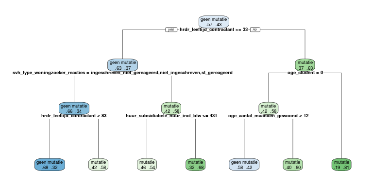

```r
rpart.plot(m.tree,extra = 4,cex=0.6)
```

## Rules

```r
rpart.rules(m.tree, clip.facs = TRUE, cover = TRUE, extra = 4)
```

```
##  oge_mutatie_label  gee mut                                                                                                                                                                                                                  cover
##       geen mutatie [.68 .32] when hrdr_leeftijd_contractant is 33 to 83 & ingeschreven_niet_gereageerd or niet_ingeschreven or st_gereageerd                                                                                                   60%
##       geen mutatie [.58 .42] when hrdr_leeftijd_contractant <  33                                                                            & not oge_student & oge_aantal_maanden_gewoond <  12                                               3%
##            mutatie [.46 .54] when hrdr_leeftijd_contractant >=       33 &                                     de_gereageerd or ds_gereageerd                                                      & huur_subsidiabele_huur_incl_btw >= 431      8%
##            mutatie [.42 .58] when hrdr_leeftijd_contractant >=       83 & ingeschreven_niet_gereageerd or niet_ingeschreven or st_gereageerd                                                                                                    5%
##            mutatie [.40 .60] when hrdr_leeftijd_contractant <  33                                                                            & not oge_student & oge_aantal_maanden_gewoond >= 12                                              16%
##            mutatie [.32 .68] when hrdr_leeftijd_contractant >=       33 &                                     de_gereageerd or ds_gereageerd                                                      & huur_subsidiabele_huur_incl_btw <  431      3%
##            mutatie [.19 .81] when hrdr_leeftijd_contractant <  33                                                                            & oge_student                                                                                      5%
```

## Correlatie : Co-lineariteit checken

Voor een linear-regressie model is het van belang dat de verklarende variabelen niet al te zwaar gecorreleerd zijn.

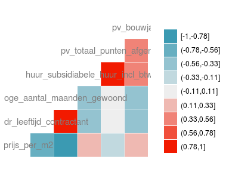

```r
require(GGally, quietly = TRUE)
df.c <- cor(df[c("calc_prijs_per_m2","hrdr_leeftijd_contractant",
                 "oge_aantal_maanden_gewoond","huur_subsidiabele_huur_incl_btw",
                 "pv_totaal_punten_afgerond","pv_bouwjaar")],method = "spearman")

ggcorr(df.c, nbreaks = 9, label = FALSE, label_size = 2, color = "grey50")
```

## Logistic regression

Logistiche regressie is nog steeds een heel veel gebruikte techniek. Grote voordeel is dat de bijdrage van iedere verklarende variabele onafhankelijk van elkaar kan worden geinterpreteerd en dat de uitkomst een kans is.

```r
# fit model
m.glm <- glm(oge_mutatie_label ~ scale(oge_aantal_maanden_gewoond) +
              log10(huur_subsidiabele_huur_incl_btw+1) + oge_oge_type +
              scale(hrdr_leeftijd_contractant) + oge_student,
          data = df,
          family = binomial )
```

## Model summary

```r
summary(m.glm)
```

```
##
## Call:
## glm(formula = oge_mutatie_label ~ scale(oge_aantal_maanden_gewoond) +
##     log10(huur_subsidiabele_huur_incl_btw + 1) + oge_oge_type +
##     scale(hrdr_leeftijd_contractant) + oge_student, family = binomial,
##     data = df)
##
## Deviance Residuals:
##     Min       1Q   Median       3Q      Max
## -1.9106  -1.0521  -0.8519   1.2408   2.0734
##
## Coefficients:
##                                            Estimate Std. Error z value Pr(>|z|)
## (Intercept)                                 2.79540    0.41363   6.758 1.40e-11
## scale(oge_aantal_maanden_gewoond)          -0.23398    0.01956 -11.962  < 2e-16
## log10(huur_subsidiabele_huur_incl_btw + 1) -1.14973    0.15495  -7.420 1.17e-13
## oge_oge_typeEW                             -0.29799    0.05544  -5.375 7.68e-08
## oge_oge_typeMA                             -0.28480    0.06621  -4.302 1.70e-05
## scale(hrdr_leeftijd_contractant)           -0.08634    0.01852  -4.663 3.12e-06
## oge_student                                 1.25123    0.08951  13.979  < 2e-16
##
## (Intercept)                                ***
## scale(oge_aantal_maanden_gewoond)          ***
## log10(huur_subsidiabele_huur_incl_btw + 1) ***
## oge_oge_typeEW                             ***
## oge_oge_typeMA                             ***
## scale(hrdr_leeftijd_contractant)           ***
## oge_student                                ***
## ---
## Signif. codes:  0 '***' 0.001 '**' 0.01 '*' 0.05 '.' 0.1 ' ' 1
##
## (Dispersion parameter for binomial family taken to be 1)
##
##     Null deviance: 25879  on 18905  degrees of freedom
## Residual deviance: 24747  on 18899  degrees of freedom
## AIC: 24761
##
## Number of Fisher Scoring iterations: 4
```

```r
#backwards = step(m.glm)
```

## Validatie van het classificatie model

```r
# we validate the model against the validation data
glm.predicted <- predict(m.glm, newdata = df.tst, type="response",se.fit=FALSE) # type = "response" gives probabilities

# confusion matrix
# create a class outcome based on cut-off being the base propensity
base.prop.tst <- prop.table(table(df.tst$oge_mutatie_label))[2] # basic R table magic
# stratified propensity on training data
base.prop.trn <- prop.table(table(df$oge_mutatie_label))[2] # basic R table magic
pred.class <- (glm.predicted > base.prop.trn)

# confusion matrix
table(as.numeric(pred.class),df.tst$oge_mutatie_label)
```

```
##
##     geen mutatie mutatie
##   0        19635     894
##   1         9017     713
```

Wat valt je op?

## ROC curves

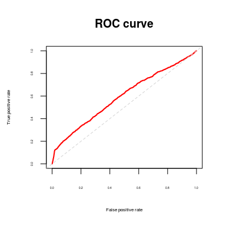

```r
library(ROCR)
glm.pred <- prediction(glm.predicted,df.tst$oge_mutatie_label)
glm.perf <- performance(glm.pred, "tpr", "fpr")

# ROC curve
op<-par(no.readonly=TRUE) #this is done to save the default settings
par(cex.lab=0.5,cex.axis=0.3)
plot(glm.perf, col="red", lwd= 2, main= "ROC curve")
abline(0, 1, untf = FALSE, col = "lightgray", lty = 2)
```

```r
par(op) #re-set the plot to the default settings
```

## Validatie beslisboom

```r
library(ROCR)

dt.predicted <- predict(m.tree, newdata = df.tst)#, type="class")
dt.pred <- prediction(dt.predicted[,2],df.tst$oge_mutatie_label)
dt.perf <- performance(dt.pred, "tpr", "fpr")

base.prop.trn <- prop.table(table(df$oge_mutatie_label))[2] # basic R table magic
pred.class <- (dt.predicted[,2] > base.prop.trn)

# confusion matrix
table(as.numeric(pred.class),df.tst$oge_mutatie_label)
```

```
##
##     geen mutatie mutatie
##   0        19946     707
##   1         8706     900
```

## Random Forest

Een random-forest maakt een heel bos van beslisbomen.

```r
library(randomForest)

# more generic approach
rf.formula <- as.formula("oge_mutatie_label ~ oge_aantal_maanden_gewoond +
              huur_subsidiabele_huur_incl_btw + hrdr_samenstelling +
              oge_oge_type +
              hrdr_leeftijd_contractant + oge_student")

# build rf model
m.rf <- randomForest(rf.formula, df)
# random forests work best on stratified training data, blcd stands for balanced
m.rf.blcd <- randomForest(rf.formula, df, sampsize = c(1000,1000) )
```

## Variabele importance

Deze plot laat zien hoe belangrijk individuele verklarende variabelen zijn. De plot wordt gemaakt door de prestatie van het bs te vergelijken met hetzelfde bos maar dan zonder alle bomen waarin die verklarende variabele zit. Het verschil is dus hoeveel de prestatie afneemt als we die verklarende variabele niet gebruiken.

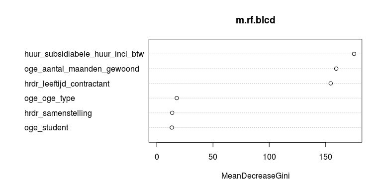

```r
varImpPlot(m.rf.blcd)
```

## Validatie random forest

```r
library(ROCR)
# run model agains test data
rf.predicted <- predict(m.rf.blcd, newdata = df.tst, type = 'prob')
rf.pred <- prediction(rf.predicted[,2], df.tst$oge_mutatie_label)
rf.perf <- performance(rf.pred, "tpr", "fpr")
```

## ROC curves

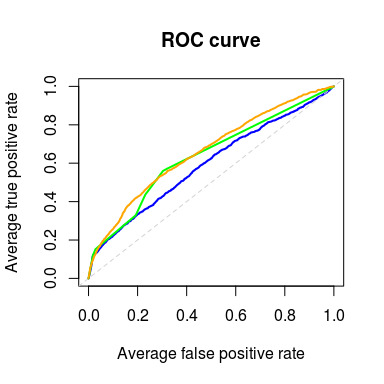

```r
# ROC curve
plot(glm.perf, avg= "threshold", col="blue", lwd= 2, main= "ROC curve")
abline(0, 1, untf = FALSE, col = "lightgray", lty = 2)
# plot ROC curve of tree model
plot(dt.perf, add=TRUE, col='Green', lwd= 2, main= "ROC curve")
# plot ROC curve of random forest model
plot(rf.perf, add=TRUE, col='Orange', lwd= 2, main= "ROC curve")
```

## Business case

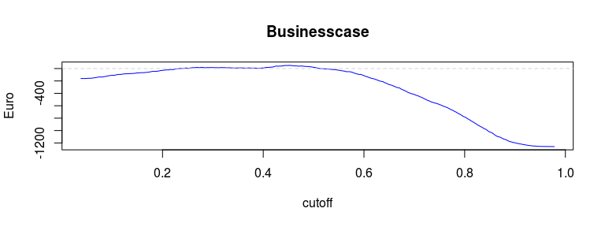

```r
# cost matrix in euros [TP FP, FN TN]
m.cost <- matrix(c(1, -.1, -.1, 0), nrow = 2, ncol =2)

pred <- rf.pred
m.pred <- cbind(pred@tp[[1]], pred@fp[[1]], pred@fn[[1]], pred@tn[[1]])

business.case <- m.pred %*% as.vector(m.cost) # sum all margins

plot(sort(pred@cutoffs[[1]]),business.case,
     type='l', col='blue',
     main='Businesscase',xlab='cutoff',ylab='Euro')
abline(0, 0, col = "lightgray", lty = 2)
```

## Resultaat

Als resultaat van deze stap hebben we een aantal model technieken op deze dataset los gelaten en getest op de test set. De resultaten zijn gepresenteerd in een zogenaamde confusion matrix en in een ROC curve.

Met een simpele evaluatie van de confusion matrix kunnen we een businesscase doorrekenen.

Voor de toepassing in het onderhoudsvraagstuk en dus de investering per asset lijkt deze aanpak beperkt bruikbaar.

We gaan verder onderzoeken of een survival analyse een meer toepasbaar resultaat kan opleveren op asset niveau.